# Correlaciones entre variables del Censo de PERSONAS y CASEN a nivel de Zona Censal IV

### 1.2 **P09**: Edad

(0-100)  
100 años y más

#### 1.2.1 Queremos saber la frecuencia de personas entre 40 y 49 años que viven por comuna:

```r
tabla_con_clave <- readRDS("censo_personas_con_clave_17.rds")
```

```r
b <- tabla_con_clave$COMUNA
c <- tabla_con_clave$P09
cross_tab =  xtabs( ~ unlist(b) + unlist(c))
tabla <- as.data.frame(cross_tab)
d <-tabla[!(tabla$Freq == 0),]
names(d)[1] <- "comuna"
names(d)[2] <- "edad"
d$anio <- "2017"

# Hay que construir un dataframe solo con el rango de edad entre 40 y 49 años:

d_rango <- filter(d, as.numeric(d$edad) > 40 & as.numeric(d$edad) < 51)
```

para nuestro requerimiento los rangos deben establecerse entre > 40 y < 51

```r
head(d_rango,10)
```

```
##    comuna edad Freq anio
## 1    1101   40 2816 2017
## 2    1107   40 1419 2017
## 3    1401   40  213 2017
## 4    1402   40   21 2017
## 5    1403   40   22 2017
## 6    1404   40   26 2017
## 7    1405   40  200 2017
## 8    2101   40 5299 2017
## 9    2102   40  201 2017
## 10   2103   40  307 2017
```

```r
tail(d_rango,10)
```

```
##      comuna edad Freq anio
## 3451  16203   49  238 2017
## 3452  16204   49   96 2017
## 3453  16205   49   82 2017
## 3454  16206   49   92 2017
## 3455  16207   49   94 2017
## 3456  16301   49  803 2017
## 3457  16302   49  405 2017
## 3458  16303   49  170 2017
## 3459  16304   49   68 2017
## 3460  16305   49  188 2017
```

```r
# Hay que sumar todos los rangos:
d_rango_sum <- aggregate(d_rango$Freq, by=list(Category=d_rango$comuna), FUN=sum)

# Agregamos un cero al codigo comunal de cuatro cifras:

# recogemos el campo Comuna:
codigos <- d_rango_sum$Category
# construimos una secuencia llamada rango del 1 al total de filas del dataset:
rango <- seq(1:nrow(d_rango_sum))
# Creamos un string que agrega un cero a todos los registros:
cadena <- paste("0",codigos[rango], sep = "")

# El string cadena tiene o 5 o 6 digitos, los cuales siempre deben ser siempre 5 agregandole un cero al inicio de los que tienen 4.
# Para ello extraemos un substring de la cadena sobre todas las filas (rangos) comenzando desde el primero o el segundo y llegando siempre al 6.

cadena <- substr(cadena,(nchar(cadena)[rango])-(4),6)
codigos <- as.data.frame(codigos)
cadena <- as.data.frame(cadena)
comuna_corr <- cbind(d_rango_sum,cadena)

comuna_corr <- comuna_corr[,-c(1),drop=FALSE]
names(comuna_corr)[2] <- "código"
```

Unimos con ingresos promedios expandidos:

```r
df_2017_2 = merge( x = comuna_corr, y = ingresos_expandidos_2017, by = "código", all.x = TRUE)

names(df_2017_2)[2] <- "40_49"

tablamadre <- head(df_2017_2,50)

kbl(tablamadre) %>%
  kable_styling(bootstrap_options = c("striped", "hover")) %>%
  kable_paper() %>%
  scroll_box(width = "100%", height = "300px")
```

| código | 40_49 | comuna.x | promedio_i | año | comuna.y | personas | Ingresos_expandidos |
| --- | --- | --- | --- | --- | --- | --- | --- |
| 01101 | 24918 | Iquique | 354820.7 | 2017 | 1101 | 191468 | 67936815240 |
| 01107 | 13429 | Alto Hospicio | 301933.4 | 2017 | 1107 | 108375 | 32722034397 |
| 01401 | 2034 | Pozo Almonte | 285981.8 | 2017 | 1401 | 15711 | 4493059532 |
| 01402 | 173 | Camiña | 262850.3 | 2017 | 1402 | 1250 | 328562901 |
| 01403 | 227 | NA | NA | NA | NA | NA | NA |
| 01404 | 325 | Huara | 253968.5 | 2017 | 1404 | 2730 | 693334131 |
| 01405 | 1916 | Pica | 313007.5 | 2017 | 1405 | 9296 | 2909717399 |
| 02101 | 50203 | Antofagasta | 347580.2 | 2017 | 2101 | 361873 | 125779893517 |
| 02102 | 2096 | Mejillones | 369770.7 | 2017 | 2102 | 13467 | 4979702302 |
| 02103 | 2787 | Sierra Gorda | 403458.5 | 2017 | 2103 | 10186 | 4109628188 |
| 02104 | 1976 | Taltal | 364539.1 | 2017 | 2104 | 13317 | 4854566842 |
| 02201 | 23872 | Calama | 409671.3 | 2017 | 2201 | 165731 | 67895226712 |
| 02202 | 56 | NA | NA | NA | NA | NA | NA |
| 02203 | 1722 | San Pedro de Atacama | 426592.0 | 2017 | 2203 | 10996 | 4690805471 |
| 02301 | 3148 | Tocopilla | 246615.3 | 2017 | 2301 | 25186 | 6211253937 |
| 02302 | 1177 | María Elena | 466266.9 | 2017 | 2302 | 6457 | 3010685220 |
| 03101 | 20052 | Copiapó | 330075.2 | 2017 | 3101 | 153937 | 50810778473 |
| 03102 | 2192 | Caldera | 299314.8 | 2017 | 3102 | 17662 | 5286498241 |
| 03103 | 2009 | Tierra Amarilla | 314643.9 | 2017 | 3103 | 14019 | 4410992711 |
| 03201 | 1505 | Chañaral | 286389.3 | 2017 | 3201 | 12219 | 3499391196 |
| 03202 | 2131 | Diego de Almagro | 336256.8 | 2017 | 3202 | 13925 | 4682376047 |
| 03301 | 6595 | Vallenar | 304336.7 | 2017 | 3301 | 51917 | 15800246795 |
| 03302 | 750 | Alto del Carmen | 227130.4 | 2017 | 3302 | 5299 | 1203563833 |
| 03303 | 882 | Freirina | 253086.7 | 2017 | 3303 | 7041 | 1781983257 |
| 03304 | 1232 | Huasco | 287406.6 | 2017 | 3304 | 10149 | 2916889629 |
| 04101 | 28642 | La Serena | 270221.9 | 2017 | 4101 | 221054 | 59733627577 |
| 04102 | 29587 | Coquimbo | 261852.6 | 2017 | 4102 | 227730 | 59631700074 |
| 04103 | 1441 | Andacollo | 248209.3 | 2017 | 4103 | 11044 | 2741223967 |
| 04104 | 571 | La Higuera | 228356.8 | 2017 | 4104 | 4241 | 968461330 |
| 04105 | 642 | Paiguano | 205942.1 | 2017 | 4105 | 4497 | 926121774 |
| 04106 | 3774 | Vicuña | 211431.9 | 2017 | 4106 | 27771 | 5871675449 |
| 04201 | 3995 | Illapel | 238674.4 | 2017 | 4201 | 30848 | 7362627007 |
| 04202 | 1168 | Canela | 207933.6 | 2017 | 4202 | 9093 | 1890740321 |
| 04203 | 2782 | Los Vilos | 255200.4 | 2017 | 4203 | 21382 | 5456695139 |
| 04204 | 4433 | Salamanca | 242879.5 | 2017 | 4204 | 29347 | 7127783272 |
| 04301 | 14439 | Ovalle | 266522.9 | 2017 | 4301 | 111272 | 29656533187 |
| 04302 | 1913 | Combarbalá | 210409.7 | 2017 | 4302 | 13322 | 2803077721 |
| 04303 | 4153 | Monte Patria | 211907.9 | 2017 | 4303 | 30751 | 6516380780 |
| 04304 | 1407 | Punitaqui | 194997.8 | 2017 | 4304 | 10956 | 2136395349 |
| 04305 | 537 | Río Hurtado | 182027.2 | 2017 | 4305 | 4278 | 778712384 |
| 05101 | 35900 | Valparaíso | 298720.7 | 2017 | 5101 | 296655 | 88616992249 |
| 05102 | 3718 | Casablanca | 312802.7 | 2017 | 5102 | 26867 | 8404070481 |
| 05103 | 5763 | Concón | 318496.3 | 2017 | 5103 | 42152 | 13425257057 |
| 05104 | 126 | NA | NA | NA | NA | NA | NA |
| 05105 | 2420 | Puchuncaví | 288737.2 | 2017 | 5105 | 18546 | 5354920887 |
| 05107 | 4089 | Quintero | 316659.1 | 2017 | 5107 | 31923 | 10108709691 |
| 05109 | 38544 | Viña del Mar | 337006.1 | 2017 | 5109 | 334248 | 112643604611 |
| 05201 | 1105 | NA | NA | NA | NA | NA | NA |
| 05301 | 9106 | Los Andes | 338182.5 | 2017 | 5301 | 66708 | 22559476922 |
| 05302 | 1927 | Calle Larga | 245165.4 | 2017 | 5302 | 14832 | 3636293159 |

Correlacionamos:

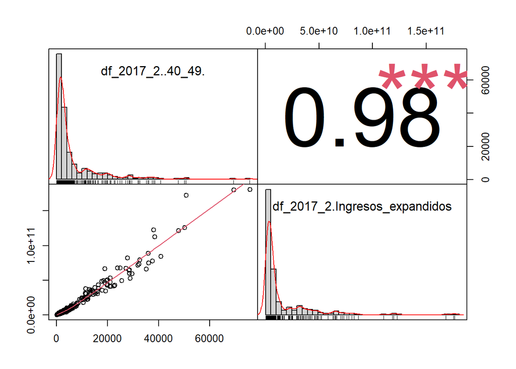

```r
dat1 <- data.frame(df_2017_2$`40_49`, df_2017_2$Ingresos_expandidos)
chart.Correlation(dat1)
```

#### 1.2.2 Queremos saber la frecuencia de personas entre 30 y 39 años que viven por comuna:

```r
b <- tabla_con_clave$COMUNA
c <- tabla_con_clave$P09
cross_tab =  xtabs( ~ unlist(b) + unlist(c))
tabla <- as.data.frame(cross_tab)
d <-tabla[!(tabla$Freq == 0),]
names(d)[1] <- "comuna"
names(d)[2] <- "edad"
d$anio <- "2017"
```

```r
# Hay que construir un dataframe solo con el rango de edad entre 30 y 39 años:

d_rango <- filter(d, as.numeric(d$edad) > 30 & as.numeric(d$edad) < 41)

# Hay que sumar todos los rangos:
d_rango_sum <- aggregate(d_rango$Freq, by=list(Category=d_rango$comuna), FUN=sum)

# Agregamos un cero al codigo comunal de cuatro cifras:

# recogemos el campo Comuna:
codigos <- d_rango_sum$Category
# construimos una secuencia llamada rango del 1 al total de filas del dataset:
rango <- seq(1:nrow(d_rango_sum))
# Creamos un string que agrega un cero a todos los registros:
cadena <- paste("0",codigos[rango], sep = "")

# El string cadena tiene o 5 o 6 digitos, los cuales siempre deben ser siempre 5 agregandole un cero al inicio de los que tienen 4.
# Para ello extraemos un substring de la cadena sobre todas las filas (rangos) comenzando desde el primero o el segundo y llegando siempre al 6.

cadena <- substr(cadena,(nchar(cadena)[rango])-(4),6)
codigos <- as.data.frame(codigos)
cadena <- as.data.frame(cadena)
comuna_corr <- cbind(d_rango_sum,cadena)

comuna_corr <- comuna_corr[,-c(1),drop=FALSE]
names(comuna_corr)[2] <- "código"
```

Unimos con ingresos promedios expandidos:

```r
df_2017_2 = merge( x = comuna_corr, y = ingresos_expandidos_2017, by = "código", all.x = TRUE)

names(df_2017_2)[2] <- "30_39"

tablamadre <- head(df_2017_2,50)

kbl(tablamadre) %>%
  kable_styling(bootstrap_options = c("striped", "hover")) %>%
  kable_paper() %>%
  scroll_box(width = "100%", height = "300px")
```

| código | 30_39 | comuna.x | promedio_i | año | comuna.y | personas | Ingresos_expandidos |
| --- | --- | --- | --- | --- | --- | --- | --- |
| 01101 | 31454 | Iquique | 354820.7 | 2017 | 1101 | 191468 | 67936815240 |
| 01107 | 16399 | Alto Hospicio | 301933.4 | 2017 | 1107 | 108375 | 32722034397 |
| 01401 | 2650 | Pozo Almonte | 285981.8 | 2017 | 1401 | 15711 | 4493059532 |
| 01402 | 134 | Camiña | 262850.3 | 2017 | 1402 | 1250 | 328562901 |
| 01403 | 290 | NA | NA | NA | NA | NA | NA |
| 01404 | 368 | Huara | 253968.5 | 2017 | 1404 | 2730 | 693334131 |
| 01405 | 2235 | Pica | 313007.5 | 2017 | 1405 | 9296 | 2909717399 |
| 02101 | 57275 | Antofagasta | 347580.2 | 2017 | 2101 | 361873 | 125779893517 |
| 02102 | 2343 | Mejillones | 369770.7 | 2017 | 2102 | 13467 | 4979702302 |
| 02103 | 3226 | Sierra Gorda | 403458.5 | 2017 | 2103 | 10186 | 4109628188 |
| 02104 | 2119 | Taltal | 364539.1 | 2017 | 2104 | 13317 | 4854566842 |
| 02201 | 28132 | Calama | 409671.3 | 2017 | 2201 | 165731 | 67895226712 |
| 02202 | 70 | NA | NA | NA | NA | NA | NA |
| 02203 | 2458 | San Pedro de Atacama | 426592.0 | 2017 | 2203 | 10996 | 4690805471 |
| 02301 | 3461 | Tocopilla | 246615.3 | 2017 | 2301 | 25186 | 6211253937 |
| 02302 | 1316 | María Elena | 466266.9 | 2017 | 2302 | 6457 | 3010685220 |
| 03101 | 22252 | Copiapó | 330075.2 | 2017 | 3101 | 153937 | 50810778473 |
| 03102 | 2440 | Caldera | 299314.8 | 2017 | 3102 | 17662 | 5286498241 |
| 03103 | 2083 | Tierra Amarilla | 314643.9 | 2017 | 3103 | 14019 | 4410992711 |
| 03201 | 1632 | Chañaral | 286389.3 | 2017 | 3201 | 12219 | 3499391196 |
| 03202 | 2292 | Diego de Almagro | 336256.8 | 2017 | 3202 | 13925 | 4682376047 |
| 03301 | 7013 | Vallenar | 304336.7 | 2017 | 3301 | 51917 | 15800246795 |
| 03302 | 720 | Alto del Carmen | 227130.4 | 2017 | 3302 | 5299 | 1203563833 |
| 03303 | 887 | Freirina | 253086.7 | 2017 | 3303 | 7041 | 1781983257 |
| 03304 | 1409 | Huasco | 287406.6 | 2017 | 3304 | 10149 | 2916889629 |
| 04101 | 29444 | La Serena | 270221.9 | 2017 | 4101 | 221054 | 59733627577 |
| 04102 | 31304 | Coquimbo | 261852.6 | 2017 | 4102 | 227730 | 59631700074 |
| 04103 | 1294 | Andacollo | 248209.3 | 2017 | 4103 | 11044 | 2741223967 |
| 04104 | 502 | La Higuera | 228356.8 | 2017 | 4104 | 4241 | 968461330 |
| 04105 | 577 | Paiguano | 205942.1 | 2017 | 4105 | 4497 | 926121774 |
| 04106 | 3607 | Vicuña | 211431.9 | 2017 | 4106 | 27771 | 5871675449 |
| 04201 | 4046 | Illapel | 238674.4 | 2017 | 4201 | 30848 | 7362627007 |
| 04202 | 1011 | Canela | 207933.6 | 2017 | 4202 | 9093 | 1890740321 |
| 04203 | 3037 | Los Vilos | 255200.4 | 2017 | 4203 | 21382 | 5456695139 |
| 04204 | 4510 | Salamanca | 242879.5 | 2017 | 4204 | 29347 | 7127783272 |
| 04301 | 14914 | Ovalle | 266522.9 | 2017 | 4301 | 111272 | 29656533187 |
| 04302 | 1600 | Combarbalá | 210409.7 | 2017 | 4302 | 13322 | 2803077721 |
| 04303 | 3865 | Monte Patria | 211907.9 | 2017 | 4303 | 30751 | 6516380780 |
| 04304 | 1405 | Punitaqui | 194997.8 | 2017 | 4304 | 10956 | 2136395349 |
| 04305 | 501 | Río Hurtado | 182027.2 | 2017 | 4305 | 4278 | 778712384 |
| 05101 | 39802 | Valparaíso | 298720.7 | 2017 | 5101 | 296655 | 88616992249 |
| 05102 | 3613 | Casablanca | 312802.7 | 2017 | 5102 | 26867 | 8404070481 |
| 05103 | 5373 | Concón | 318496.3 | 2017 | 5103 | 42152 | 13425257057 |
| 05104 | 184 | NA | NA | NA | NA | NA | NA |
| 05105 | 2438 | Puchuncaví | 288737.2 | 2017 | 5105 | 18546 | 5354920887 |
| 05107 | 4151 | Quintero | 316659.1 | 2017 | 5107 | 31923 | 10108709691 |
| 05109 | 43798 | Viña del Mar | 337006.1 | 2017 | 5109 | 334248 | 112643604611 |
| 05201 | 1535 | NA | NA | NA | NA | NA | NA |
| 05301 | 9604 | Los Andes | 338182.5 | 2017 | 5301 | 66708 | 22559476922 |
| 05302 | 2093 | Calle Larga | 245165.4 | 2017 | 5302 | 14832 | 3636293159 |

Correlacionamos:

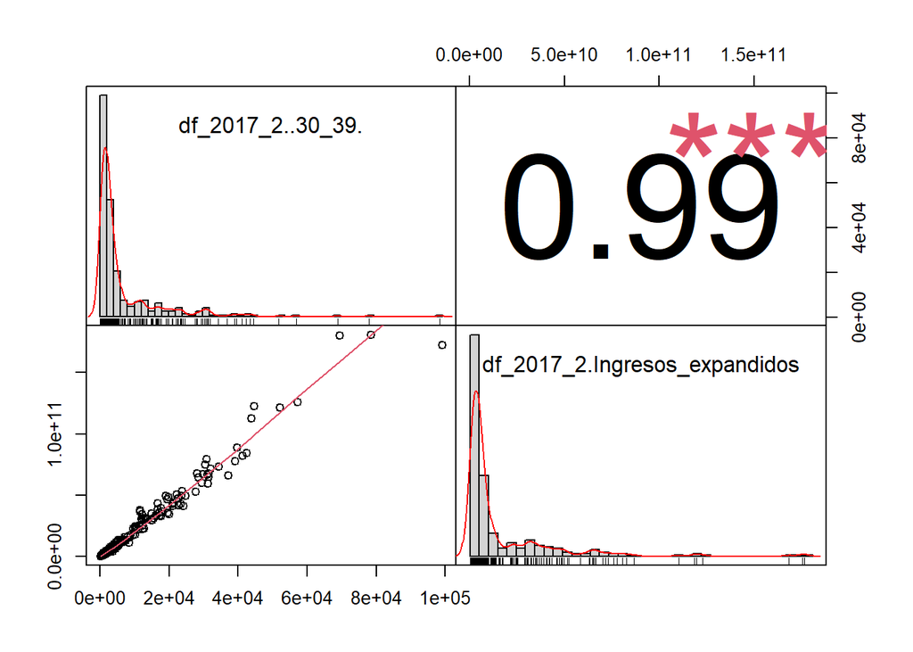

```r
dat1 <- data.frame(df_2017_2$`30_39`, df_2017_2$Ingresos_expandidos)
chart.Correlation(dat1)
```

1. Hay que analizar la relevancia de las preguntas de la P10 a la P13
2. Hay que hacer un análisis conjunto entre P14 (Curso o año más alto aprobado), P15 (Nivel del curso más alto aprobado) y P15A (Completó el nivel especificado).

### 1.3 **P15**: Nivel del curso más alto aprobado

1 Sala cuna o jardín infantil  
2 Prekínder  
3 Kínder  
4 Especial o diferencial  
5 Educación básica  
6 Primaria o preparatorio (sistema antiguo)  
7 Científico-humanista  
8 Técnica profesional  
9 Humanidades (sistema antiguo)  
10 Técnica comercial, industrial/normalista (sistema antiguo)  
11 Técnico superior (1-3 años)  
12 Profesional (4 o más años)  
13 Magíster  
14 Doctorado  
98 No aplica  
99 Missing

#### 1.3.1 Queremos saber la frecuencia de personas por nivel que viven por comuna:

Leemos la base de datos Censal:

```r
tabla_con_clave <- readRDS("censo_personas_con_clave_17.rds")
```

```r
b <- tabla_con_clave$COMUNA
c <- tabla_con_clave$P15
cross_tab =  xtabs( ~ unlist(b) + unlist(c))
tabla <- as.data.frame(cross_tab)
d <-tabla[!(tabla$Freq == 0),]
names(d)[1] <- "comuna"
names(d)[2] <- "nivel"
```

```r
tablamadre <- head(d,50)

kbl(tablamadre) %>%
  kable_styling(bootstrap_options = c("striped", "hover")) %>%
  kable_paper() %>%
  scroll_box(width = "100%", height = "300px")
```

| comuna | nivel | Freq |
| --- | --- | --- |
| 1101 | 1 | 5890 |
| 1107 | 1 | 4592 |
| 1401 | 1 | 532 |
| 1402 | 1 | 42 |
| 1403 | 1 | 29 |
| 1404 | 1 | 74 |
| 1405 | 1 | 200 |
| 2101 | 1 | 9518 |
| 2102 | 1 | 335 |
| 2103 | 1 | 46 |
| 2104 | 1 | 348 |
| 2201 | 1 | 3849 |
| 2202 | 1 | 9 |
| 2203 | 1 | 260 |
| 2301 | 1 | 764 |
| 2302 | 1 | 100 |
| 3101 | 1 | 4781 |
| 3102 | 1 | 566 |
| 3103 | 1 | 468 |
| 3201 | 1 | 417 |
| 3202 | 1 | 508 |
| 3301 | 1 | 1674 |
| 3302 | 1 | 150 |
| 3303 | 1 | 270 |
| 3304 | 1 | 398 |
| 4101 | 1 | 6654 |
| 4102 | 1 | 7007 |
| 4103 | 1 | 302 |
| 4104 | 1 | 133 |
| 4105 | 1 | 140 |
| 4106 | 1 | 783 |
| 4201 | 1 | 959 |
| 4202 | 1 | 198 |
| 4203 | 1 | 565 |
| 4204 | 1 | 710 |
| 4301 | 1 | 3230 |
| 4302 | 1 | 290 |
| 4303 | 1 | 714 |
| 4304 | 1 | 233 |
| 4305 | 1 | 110 |
| 5101 | 1 | 6687 |
| 5102 | 1 | 733 |
| 5103 | 1 | 1177 |
| 5104 | 1 | 39 |
| 5105 | 1 | 505 |
| 5107 | 1 | 790 |
| 5109 | 1 | 7339 |
| 5201 | 1 | 262 |
| 5301 | 1 | 1688 |
| 5302 | 1 | 404 |

Apilamos los registros comunales uno al lado del otro:

```r
d_t <- filter(d,d$nivel == 1)
for(i in 2:17){
  d_i <- filter(d,d$nivel == i)
  d_t = merge( x = d_t, y = d_i, by = "comuna", all.x = TRUE)
}
```

Agregamos un cero a los codigos comunales de 4 digitos:

```r
codigos <- d_t$comuna
rango <- seq(1:nrow(d_t))
cadena <- paste("0",codigos[rango], sep = "")
cadena <- substr(cadena,(nchar(cadena)[rango])-(4),6)
codigos <- as.data.frame(codigos)
cadena <- as.data.frame(cadena)
comuna_corr <- cbind(d_t,cadena)
comuna_corr <- comuna_corr[,-c(1),drop=FALSE]
names(comuna_corr)[35] <- "código"
```

```r
tablamadre <- head(comuna_corr,50)

kbl(tablamadre) %>%
  kable_styling(bootstrap_options = c("striped", "hover")) %>%
  kable_paper() %>%
  scroll_box(width = "100%", height = "300px")
```

| nivel.x | Freq.x | nivel.y | Freq.y | nivel.x.1 | Freq.x.1 | nivel.y.1 | Freq.y.1 | nivel.x.2 | Freq.x.2 | nivel.y.2 | Freq.y.2 | nivel.x.3 | Freq.x.3 | nivel.y.3 | Freq.y.3 | nivel.x.4 | Freq.x.4 | nivel.y.4 | Freq.y.4 | nivel.x.5 | Freq.x.5 | nivel.y.5 | Freq.y.5 | nivel.x.6 | Freq.x.6 | nivel.y.6 | Freq.y.6 | nivel.x.7 | Freq.x.7 | … |
| --- | --- | --- | --- | --- | --- | --- | --- | --- | --- | --- | --- | --- | --- | --- | --- | --- | --- | --- | --- | --- | --- | --- | --- | --- | --- | --- | --- | --- | --- | --- |
| 1 | 5890 | 2 | 2977 | 3 | 4311 | 4 | 629 | 5 | 35364 | 6 | 3734 | 7 | 42856 | 8 | 26764 | 9 | 3945 | 10 | 2260 | 11 | 14681 | 12 | 35222 | 13 | 2288 | 14 | 281 | NA | NA | … |
| 1 | 4592 | 2 | 2302 | 3 | 3166 | 4 | 482 | 5 | 31291 | 6 | 1257 | 7 | 25030 | 8 | 19924 | 9 | 969 | 10 | 406 | 11 | 4220 | 12 | 6395 | 13 | 178 | 14 | 12 | NA | NA | … |
| 1 | 532 | 2 | 273 | 3 | 380 | 4 | 19 | 5 | 4181 | 6 | 302 | 7 | 3790 | 8 | 2748 | 9 | 159 | 10 | 69 | 11 | 979 | 12 | 1136 | 13 | 68 | 14 | 4 | NA | NA | … |
| 1 | 42 | 2 | 5 | 3 | 28 | NA | NA | 5 | 518 | 6 | 35 | 7 | 181 | 8 | 145 | 9 | 1 | 10 | 1 | 11 | 22 | 12 | 62 | 13 | 12 | 14 | 1 | NA | NA | … |
| 1 | 29 | 2 | 12 | 3 | 27 | 4 | 7 | 5 | 661 | 6 | 18 | 7 | 213 | 8 | 213 | 9 | 6 | 10 | 1 | 11 | 110 | 12 | 149 | 13 | 9 | 14 | 3 | NA | NA | … |
| 1 | 74 | 2 | 36 | 3 | 63 | 4 | 3 | 5 | 1024 | 6 | 98 | 7 | 510 | 8 | 343 | 9 | 19 | 10 | 20 | 11 | 95 | 12 | 135 | 13 | 11 | 14 | 1 | NA | NA | … |
| 1 | 200 | 2 | 75 | 3 | 132 | 4 | 19 | 5 | 1475 | 6 | 137 | 7 | 2056 | 8 | 2010 | 9 | 78 | 10 | 63 | 11 | 995 | 12 | 1499 | 13 | 153 | 14 | 5 | NA | NA | … |
| 1 | 9518 | 2 | 5095 | 3 | 8011 | 4 | 1296 | 5 | 71800 | 6 | 6068 | 7 | 81128 | 8 | 53259 | 9 | 5956 | 10 | 2993 | 11 | 27914 | 12 | 60800 | 13 | 3799 | 14 | 738 | NA | NA | … |
| 1 | 335 | 2 | 175 | 3 | 277 | 4 | 41 | 5 | 3063 | 6 | 222 | 7 | 4078 | 8 | 2325 | 9 | 103 | 10 | 61 | 11 | 854 | 12 | 1003 | 13 | 25 | 14 | 5 | NA | NA | … |
| 1 | 46 | 2 | 25 | 3 | 31 | NA | NA | 5 | 602 | 6 | 26 | 7 | 2757 | 8 | 2434 | 9 | 38 | 10 | 40 | 11 | 1510 | 12 | 2306 | 13 | 262 | 14 | 3 | NA | NA | … |
| 1 | 348 | 2 | 176 | 3 | 272 | 4 | 34 | 5 | 3782 | 6 | 311 | 7 | 2825 | 8 | 2601 | 9 | 156 | 10 | 89 | 11 | 670 | 12 | 1025 | 13 | 45 | 14 | 5 | NA | NA | … |
| 1 | 3849 | 2 | 2178 | 3 | 3610 | 4 | 584 | 5 | 35342 | 6 | 2165 | 7 | 41401 | 8 | 24017 | 9 | 1795 | 10 | 971 | 11 | 13498 | 12 | 20699 | 13 | 1128 | 14 | 115 | NA | NA | … |
| 1 | 9 | 2 | 3 | 3 | 5 | NA | NA | 5 | 90 | 6 | 6 | 7 | 70 | 8 | 47 | 9 | 2 | NA | NA | 11 | 25 | 12 | 34 | 13 | 3 | NA | NA | NA | NA | … |
| 1 | 260 | 2 | 115 | 3 | 194 | 4 | 13 | 5 | 2212 | 6 | 131 | 7 | 2410 | 8 | 1757 | 9 | 50 | 10 | 50 | 11 | 906 | 12 | 1846 | 13 | 203 | 14 | 52 | NA | NA | … |
| 1 | 764 | 2 | 456 | 3 | 703 | 4 | 145 | 5 | 6653 | 6 | 664 | 7 | 6511 | 8 | 3700 | 9 | 459 | 10 | 150 | 11 | 1285 | 12 | 1764 | 13 | 49 | 14 | 6 | NA | NA | … |
| 1 | 100 | 2 | 53 | 3 | 112 | 4 | 2 | 5 | 1268 | 6 | 57 | 7 | 1852 | 8 | 1294 | 9 | 65 | 10 | 14 | 11 | 532 | 12 | 791 | 13 | 45 | 14 | 2 | NA | NA | … |
| 1 | 4781 | 2 | 2719 | 3 | 3740 | 4 | 630 | 5 | 35106 | 6 | 3540 | 7 | 36296 | 8 | 18400 | 9 | 2868 | 10 | 1070 | 11 | 11684 | 12 | 22917 | 13 | 900 | 14 | 177 | NA | NA | … |
| 1 | 566 | 2 | 290 | 3 | 466 | 4 | 51 | 5 | 4573 | 6 | 408 | 7 | 4794 | 8 | 2047 | 9 | 334 | 10 | 127 | 11 | 1182 | 12 | 1553 | 13 | 70 | 14 | 7 | NA | NA | … |
| 1 | 468 | 2 | 212 | 3 | 337 | 4 | 44 | 5 | 4542 | 6 | 358 | 7 | 3293 | 8 | 2379 | 9 | 127 | 10 | 44 | 11 | 606 | 12 | 733 | 13 | 25 | 14 | 2 | NA | NA | … |
| 1 | 417 | 2 | 207 | 3 | 282 | 4 | 97 | 5 | 3347 | 6 | 554 | 7 | 2680 | 8 | 2138 | 9 | 189 | 10 | 90 | 11 | 648 | 12 | 893 | 13 | 18 | NA | NA | NA | NA | … |
| 1 | 508 | 2 | 197 | 3 | 355 | 4 | 69 | 5 | 3282 | 6 | 325 | 7 | 3457 | 8 | 2215 | 9 | 147 | 10 | 69 | 11 | 997 | 12 | 1523 | 13 | 76 | 14 | 6 | NA | NA | … |
| 1 | 1674 | 2 | 921 | 3 | 1197 | 4 | 249 | 5 | 13586 | 6 | 1336 | 7 | 11111 | 8 | 9102 | 9 | 766 | 10 | 570 | 11 | 2827 | 12 | 4418 | 13 | 176 | 14 | 38 | NA | NA | … |
| 1 | 150 | 2 | 52 | 3 | 114 | 4 | 8 | 5 | 1771 | 6 | 215 | 7 | 988 | 8 | 871 | 9 | 49 | 10 | 31 | 11 | 165 | 12 | 281 | 13 | 15 | NA | NA | NA | NA | … |
| 1 | 270 | 2 | 139 | 3 | 148 | 4 | 23 | 5 | 2281 | 6 | 209 | 7 | 1519 | 8 | 1086 | 9 | 65 | 10 | 25 | 11 | 312 | 12 | 334 | 13 | 18 | NA | NA | NA | NA | … |
| 1 | 398 | 2 | 167 | 3 | 271 | 4 | 32 | 5 | 2626 | 6 | 302 | 7 | 2392 | 8 | 1503 | 9 | 196 | 10 | 97 | 11 | 628 | 12 | 847 | 13 | 24 | 14 | 2 | NA | NA | … |
| 1 | 6654 | 2 | 3535 | 3 | 5047 | 4 | 956 | 5 | 45201 | 6 | 5006 | 7 | 47501 | 8 | 28690 | 9 | 4752 | 10 | 1872 | 11 | 16345 | 12 | 39812 | 13 | 2529 | 14 | 507 | NA | NA | … |
| 1 | 7007 | 2 | 3890 | 3 | 5454 | 4 | 1101 | 5 | 50785 | 6 | 5527 | 7 | 52386 | 8 | 33468 | 9 | 4710 | 10 | 2369 | 11 | 15424 | 12 | 29419 | 13 | 1331 | 14 | 232 | NA | NA | … |
| 1 | 302 | 2 | 198 | 3 | 276 | 4 | 19 | 5 | 3518 | 6 | 491 | 7 | 3126 | 8 | 1186 | 9 | 85 | 10 | 33 | 11 | 525 | 12 | 556 | 13 | 10 | 14 | 2 | NA | NA | … |
| 1 | 133 | 2 | 77 | 3 | 97 | 4 | 18 | 5 | 1721 | 6 | 148 | 7 | 703 | 8 | 580 | 9 | 38 | 10 | 22 | 11 | 105 | 12 | 133 | 13 | 7 | 14 | 6 | NA | NA | … |
| 1 | 140 | 2 | 50 | 3 | 82 | 4 | 10 | 5 | 1417 | 6 | 211 | 7 | 1069 | 8 | 504 | 9 | 70 | 10 | 20 | 11 | 197 | 12 | 451 | 13 | 40 | 14 | 15 | NA | NA | … |
| 1 | 783 | 2 | 482 | 3 | 677 | 4 | 68 | 5 | 9057 | 6 | 813 | 7 | 7313 | 8 | 2860 | 9 | 403 | 10 | 129 | 11 | 1206 | 12 | 2021 | 13 | 72 | 14 | 21 | NA | NA | … |
| 1 | 959 | 2 | 491 | 3 | 691 | 4 | 128 | 5 | 10258 | 6 | 929 | 7 | 7201 | 8 | 3594 | 9 | 404 | 10 | 196 | 11 | 1604 | 12 | 2137 | 13 | 88 | 14 | 12 | NA | NA | … |
| 1 | 198 | 2 | 67 | 3 | 164 | 4 | 19 | 5 | 4178 | 6 | 396 | 7 | 1582 | 8 | 718 | 9 | 51 | 10 | 20 | 11 | 285 | 12 | 377 | 13 | 10 | NA | NA | NA | NA | … |
| 1 | 565 | 2 | 337 | 3 | 474 | 4 | 94 | 5 | 6787 | 6 | 632 | 7 | 5788 | 8 | 1541 | 9 | 282 | 10 | 102 | 11 | 1252 | 12 | 1645 | 13 | 81 | 14 | 11 | NA | NA | … |
| 1 | 710 | 2 | 420 | 3 | 631 | 4 | 74 | 5 | 9795 | 6 | 806 | 7 | 7865 | 8 | 2442 | 9 | 267 | 10 | 87 | 11 | 1658 | 12 | 2295 | 13 | 114 | 14 | 12 | NA | NA | … |
| 1 | 3230 | 2 | 1855 | 3 | 2626 | 4 | 460 | 5 | 33123 | 6 | 3423 | 7 | 27089 | 8 | 14003 | 9 | 1565 | 10 | 567 | 11 | 5696 | 12 | 8941 | 13 | 308 | 14 | 55 | NA | NA | … |
| 1 | 290 | 2 | 160 | 3 | 229 | 4 | 31 | 5 | 5456 | 6 | 591 | 7 | 2925 | 8 | 998 | 9 | 110 | 10 | 39 | 11 | 488 | 12 | 772 | 13 | 31 | NA | NA | NA | NA | … |
| 1 | 714 | 2 | 432 | 3 | 735 | 4 | 89 | 5 | 13043 | 6 | 921 | 7 | 6576 | 8 | 2983 | 9 | 176 | 10 | 79 | 11 | 930 | 12 | 1174 | 13 | 33 | 14 | 3 | NA | NA | … |
| 1 | 233 | 2 | 152 | 3 | 237 | 4 | 60 | 5 | 4342 | 6 | 329 | 7 | 2490 | 8 | 959 | 9 | 99 | 10 | 29 | 11 | 372 | 12 | 455 | 13 | 21 | 14 | 1 | NA | NA | … |
| 1 | 110 | 2 | 36 | 3 | 83 | 4 | 11 | 5 | 1912 | 6 | 170 | 7 | 847 | 8 | 327 | 9 | 33 | 10 | 17 | 11 | 135 | 12 | 199 | 13 | 14 | 14 | 2 | NA | NA | … |
| 1 | 6687 | 2 | 3910 | 3 | 5405 | 4 | 1576 | 5 | 53843 | 6 | 10426 | 7 | 73967 | 8 | 33359 | 9 | 11211 | 10 | 2409 | 11 | 24447 | 12 | 48746 | 13 | 3591 | 14 | 834 | NA | NA | … |
| 1 | 733 | 2 | 405 | 3 | 553 | 4 | 136 | 5 | 7404 | 6 | 941 | 7 | 6991 | 8 | 2945 | 9 | 446 | 10 | 79 | 11 | 1817 | 12 | 2541 | 13 | 132 | 14 | 38 | NA | NA | … |
| 1 | 1177 | 2 | 623 | 3 | 794 | 4 | 124 | 5 | 7673 | 6 | 969 | 7 | 9077 | 8 | 3345 | 9 | 1068 | 10 | 226 | 11 | 3534 | 12 | 9879 | 13 | 1419 | 14 | 211 | NA | NA | … |
| 1 | 39 | 2 | 15 | 3 | 15 | 4 | 1 | 5 | 230 | 6 | 24 | 7 | 251 | 8 | 85 | 9 | 10 | 10 | 3 | 11 | 68 | 12 | 137 | 13 | 11 | 14 | 2 | NA | NA | … |
| 1 | 505 | 2 | 226 | 3 | 406 | 4 | 75 | 5 | 4669 | 6 | 853 | 7 | 5100 | 8 | 1738 | 9 | 409 | 10 | 90 | 11 | 1469 | 12 | 1780 | 13 | 96 | 14 | 11 | NA | NA | … |
| 1 | 790 | 2 | 493 | 3 | 681 | 4 | 190 | 5 | 7365 | 6 | 1142 | 7 | 8264 | 8 | 3122 | 9 | 908 | 10 | 202 | 11 | 2748 | 12 | 3495 | 13 | 208 | 14 | 49 | NA | NA | … |
| 1 | 7339 | 2 | 4047 | 3 | 5553 | 4 | 1539 | 5 | 54389 | 6 | 10098 | 7 | 72051 | 8 | 35656 | 9 | 12645 | 10 | 2919 | 11 | 29468 | 12 | 72008 | 13 | 7476 | 14 | 1636 | NA | NA | … |
| 1 | 262 | 2 | 111 | 3 | 140 | 4 | 15 | 5 | 1417 | 6 | 103 | 7 | 1636 | 8 | 834 | 9 | 91 | 10 | 17 | 11 | 853 | 12 | 1512 | 13 | 157 | 14 | 30 | NA | NA | … |
| 1 | 1688 | 2 | 929 | 3 | 1374 | 4 | 252 | 5 | 14071 | 6 | 2134 | 7 | 14949 | 8 | 10456 | 9 | 1772 | 10 | 617 | 11 | 5575 | 12 | 8071 | 13 | 428 | 14 | 51 | NA | NA | … |
| 1 | 404 | 2 | 272 | 3 | 362 | 4 | 59 | 5 | 3980 | 6 | 578 | 7 | 3199 | 8 | 2407 | 9 | 208 | 10 | 96 | 11 | 764 | 12 | 1284 | 13 | 92 | 14 | 11 | NA | NA | … |

Hacemos el merge con los ingresos comunales:

```r
ingresos_expandidos_2017 <- readRDS("ingresos_expandidos_17.rds")

df_2017_2 = merge( x = comuna_corr, y = ingresos_expandidos_2017, by = "código", all.x = TRUE)

tablamadre <- head(df_2017_2,50)

kbl(tablamadre) %>%
  kable_styling(bootstrap_options = c("striped", "hover")) %>%
  kable_paper() %>%
  scroll_box(width = "100%", height = "300px")
```

| código | nivel.x | Freq.x | nivel.y | Freq.y | nivel.x.1 | Freq.x.1 | nivel.y.1 | Freq.y.1 | nivel.x.2 | Freq.x.2 | nivel.y.2 | Freq.y.2 | nivel.x.3 | Freq.x.3 | nivel.y.3 | Freq.y.3 | nivel.x.4 | Freq.x.4 | nivel.y.4 | Freq.y.4 | nivel.x.5 | Freq.x.5 | nivel.y.5 | Freq.y.5 | nivel.x.6 | Freq.x.6 | nivel.y.6 | Freq.y.6 | nivel.x.7 | … |
| --- | --- | --- | --- | --- | --- | --- | --- | --- | --- | --- | --- | --- | --- | --- | --- | --- | --- | --- | --- | --- | --- | --- | --- | --- | --- | --- | --- | --- | --- | --- |
| 01101 | 1 | 5890 | 2 | 2977 | 3 | 4311 | 4 | 629 | 5 | 35364 | 6 | 3734 | 7 | 42856 | 8 | 26764 | 9 | 3945 | 10 | 2260 | 11 | 14681 | 12 | 35222 | 13 | 2288 | 14 | 281 | NA | … |
| 01107 | 1 | 4592 | 2 | 2302 | 3 | 3166 | 4 | 482 | 5 | 31291 | 6 | 1257 | 7 | 25030 | 8 | 19924 | 9 | 969 | 10 | 406 | 11 | 4220 | 12 | 6395 | 13 | 178 | 14 | 12 | NA | … |
| 01401 | 1 | 532 | 2 | 273 | 3 | 380 | 4 | 19 | 5 | 4181 | 6 | 302 | 7 | 3790 | 8 | 2748 | 9 | 159 | 10 | 69 | 11 | 979 | 12 | 1136 | 13 | 68 | 14 | 4 | NA | … |
| 01402 | 1 | 42 | 2 | 5 | 3 | 28 | NA | NA | 5 | 518 | 6 | 35 | 7 | 181 | 8 | 145 | 9 | 1 | 10 | 1 | 11 | 22 | 12 | 62 | 13 | 12 | 14 | 1 | NA | … |
| 01403 | 1 | 29 | 2 | 12 | 3 | 27 | 4 | 7 | 5 | 661 | 6 | 18 | 7 | 213 | 8 | 213 | 9 | 6 | 10 | 1 | 11 | 110 | 12 | 149 | 13 | 9 | 14 | 3 | NA | … |
| 01404 | 1 | 74 | 2 | 36 | 3 | 63 | 4 | 3 | 5 | 1024 | 6 | 98 | 7 | 510 | 8 | 343 | 9 | 19 | 10 | 20 | 11 | 95 | 12 | 135 | 13 | 11 | 14 | 1 | NA | … |
| 01405 | 1 | 200 | 2 | 75 | 3 | 132 | 4 | 19 | 5 | 1475 | 6 | 137 | 7 | 2056 | 8 | 2010 | 9 | 78 | 10 | 63 | 11 | 995 | 12 | 1499 | 13 | 153 | 14 | 5 | NA | … |
| 02101 | 1 | 9518 | 2 | 5095 | 3 | 8011 | 4 | 1296 | 5 | 71800 | 6 | 6068 | 7 | 81128 | 8 | 53259 | 9 | 5956 | 10 | 2993 | 11 | 27914 | 12 | 60800 | 13 | 3799 | 14 | 738 | NA | … |
| 02102 | 1 | 335 | 2 | 175 | 3 | 277 | 4 | 41 | 5 | 3063 | 6 | 222 | 7 | 4078 | 8 | 2325 | 9 | 103 | 10 | 61 | 11 | 854 | 12 | 1003 | 13 | 25 | 14 | 5 | NA | … |
| 02103 | 1 | 46 | 2 | 25 | 3 | 31 | NA | NA | 5 | 602 | 6 | 26 | 7 | 2757 | 8 | 2434 | 9 | 38 | 10 | 40 | 11 | 1510 | 12 | 2306 | 13 | 262 | 14 | 3 | NA | … |
| 02104 | 1 | 348 | 2 | 176 | 3 | 272 | 4 | 34 | 5 | 3782 | 6 | 311 | 7 | 2825 | 8 | 2601 | 9 | 156 | 10 | 89 | 11 | 670 | 12 | 1025 | 13 | 45 | 14 | 5 | NA | … |
| 02201 | 1 | 3849 | 2 | 2178 | 3 | 3610 | 4 | 584 | 5 | 35342 | 6 | 2165 | 7 | 41401 | 8 | 24017 | 9 | 1795 | 10 | 971 | 11 | 13498 | 12 | 20699 | 13 | 1128 | 14 | 115 | NA | … |
| 02202 | 1 | 9 | 2 | 3 | 3 | 5 | NA | NA | 5 | 90 | 6 | 6 | 7 | 70 | 8 | 47 | 9 | 2 | NA | NA | 11 | 25 | 12 | 34 | 13 | 3 | NA | NA | NA | … |
| 02203 | 1 | 260 | 2 | 115 | 3 | 194 | 4 | 13 | 5 | 2212 | 6 | 131 | 7 | 2410 | 8 | 1757 | 9 | 50 | 10 | 50 | 11 | 906 | 12 | 1846 | 13 | 203 | 14 | 52 | NA | … |
| 02301 | 1 | 764 | 2 | 456 | 3 | 703 | 4 | 145 | 5 | 6653 | 6 | 664 | 7 | 6511 | 8 | 3700 | 9 | 459 | 10 | 150 | 11 | 1285 | 12 | 1764 | 13 | 49 | 14 | 6 | NA | … |
| 02302 | 1 | 100 | 2 | 53 | 3 | 112 | 4 | 2 | 5 | 1268 | 6 | 57 | 7 | 1852 | 8 | 1294 | 9 | 65 | 10 | 14 | 11 | 532 | 12 | 791 | 13 | 45 | 14 | 2 | NA | … |
| 03101 | 1 | 4781 | 2 | 2719 | 3 | 3740 | 4 | 630 | 5 | 35106 | 6 | 3540 | 7 | 36296 | 8 | 18400 | 9 | 2868 | 10 | 1070 | 11 | 11684 | 12 | 22917 | 13 | 900 | 14 | 177 | NA | … |
| 03102 | 1 | 566 | 2 | 290 | 3 | 466 | 4 | 51 | 5 | 4573 | 6 | 408 | 7 | 4794 | 8 | 2047 | 9 | 334 | 10 | 127 | 11 | 1182 | 12 | 1553 | 13 | 70 | 14 | 7 | NA | … |
| 03103 | 1 | 468 | 2 | 212 | 3 | 337 | 4 | 44 | 5 | 4542 | 6 | 358 | 7 | 3293 | 8 | 2379 | 9 | 127 | 10 | 44 | 11 | 606 | 12 | 733 | 13 | 25 | 14 | 2 | NA | … |
| 03201 | 1 | 417 | 2 | 207 | 3 | 282 | 4 | 97 | 5 | 3347 | 6 | 554 | 7 | 2680 | 8 | 2138 | 9 | 189 | 10 | 90 | 11 | 648 | 12 | 893 | 13 | 18 | NA | NA | NA | … |
| 03202 | 1 | 508 | 2 | 197 | 3 | 355 | 4 | 69 | 5 | 3282 | 6 | 325 | 7 | 3457 | 8 | 2215 | 9 | 147 | 10 | 69 | 11 | 997 | 12 | 1523 | 13 | 76 | 14 | 6 | NA | … |
| 03301 | 1 | 1674 | 2 | 921 | 3 | 1197 | 4 | 249 | 5 | 13586 | 6 | 1336 | 7 | 11111 | 8 | 9102 | 9 | 766 | 10 | 570 | 11 | 2827 | 12 | 4418 | 13 | 176 | 14 | 38 | NA | … |
| 03302 | 1 | 150 | 2 | 52 | 3 | 114 | 4 | 8 | 5 | 1771 | 6 | 215 | 7 | 988 | 8 | 871 | 9 | 49 | 10 | 31 | 11 | 165 | 12 | 281 | 13 | 15 | NA | NA | NA | … |
| 03303 | 1 | 270 | 2 | 139 | 3 | 148 | 4 | 23 | 5 | 2281 | 6 | 209 | 7 | 1519 | 8 | 1086 | 9 | 65 | 10 | 25 | 11 | 312 | 12 | 334 | 13 | 18 | NA | NA | NA | … |
| 03304 | 1 | 398 | 2 | 167 | 3 | 271 | 4 | 32 | 5 | 2626 | 6 | 302 | 7 | 2392 | 8 | 1503 | 9 | 196 | 10 | 97 | 11 | 628 | 12 | 847 | 13 | 24 | 14 | 2 | NA | … |
| 04101 | 1 | 6654 | 2 | 3535 | 3 | 5047 | 4 | 956 | 5 | 45201 | 6 | 5006 | 7 | 47501 | 8 | 28690 | 9 | 4752 | 10 | 1872 | 11 | 16345 | 12 | 39812 | 13 | 2529 | 14 | 507 | NA | … |
| 04102 | 1 | 7007 | 2 | 3890 | 3 | 5454 | 4 | 1101 | 5 | 50785 | 6 | 5527 | 7 | 52386 | 8 | 33468 | 9 | 4710 | 10 | 2369 | 11 | 15424 | 12 | 29419 | 13 | 1331 | 14 | 232 | NA | … |
| 04103 | 1 | 302 | 2 | 198 | 3 | 276 | 4 | 19 | 5 | 3518 | 6 | 491 | 7 | 3126 | 8 | 1186 | 9 | 85 | 10 | 33 | 11 | 525 | 12 | 556 | 13 | 10 | 14 | 2 | NA | … |
| 04104 | 1 | 133 | 2 | 77 | 3 | 97 | 4 | 18 | 5 | 1721 | 6 | 148 | 7 | 703 | 8 | 580 | 9 | 38 | 10 | 22 | 11 | 105 | 12 | 133 | 13 | 7 | 14 | 6 | NA | … |
| 04105 | 1 | 140 | 2 | 50 | 3 | 82 | 4 | 10 | 5 | 1417 | 6 | 211 | 7 | 1069 | 8 | 504 | 9 | 70 | 10 | 20 | 11 | 197 | 12 | 451 | 13 | 40 | 14 | 15 | NA | … |
| 04106 | 1 | 783 | 2 | 482 | 3 | 677 | 4 | 68 | 5 | 9057 | 6 | 813 | 7 | 7313 | 8 | 2860 | 9 | 403 | 10 | 129 | 11 | 1206 | 12 | 2021 | 13 | 72 | 14 | 21 | NA | … |
| 04201 | 1 | 959 | 2 | 491 | 3 | 691 | 4 | 128 | 5 | 10258 | 6 | 929 | 7 | 7201 | 8 | 3594 | 9 | 404 | 10 | 196 | 11 | 1604 | 12 | 2137 | 13 | 88 | 14 | 12 | NA | … |
| 04202 | 1 | 198 | 2 | 67 | 3 | 164 | 4 | 19 | 5 | 4178 | 6 | 396 | 7 | 1582 | 8 | 718 | 9 | 51 | 10 | 20 | 11 | 285 | 12 | 377 | 13 | 10 | NA | NA | NA | … |
| 04203 | 1 | 565 | 2 | 337 | 3 | 474 | 4 | 94 | 5 | 6787 | 6 | 632 | 7 | 5788 | 8 | 1541 | 9 | 282 | 10 | 102 | 11 | 1252 | 12 | 1645 | 13 | 81 | 14 | 11 | NA | … |
| 04204 | 1 | 710 | 2 | 420 | 3 | 631 | 4 | 74 | 5 | 9795 | 6 | 806 | 7 | 7865 | 8 | 2442 | 9 | 267 | 10 | 87 | 11 | 1658 | 12 | 2295 | 13 | 114 | 14 | 12 | NA | … |
| 04301 | 1 | 3230 | 2 | 1855 | 3 | 2626 | 4 | 460 | 5 | 33123 | 6 | 3423 | 7 | 27089 | 8 | 14003 | 9 | 1565 | 10 | 567 | 11 | 5696 | 12 | 8941 | 13 | 308 | 14 | 55 | NA | … |
| 04302 | 1 | 290 | 2 | 160 | 3 | 229 | 4 | 31 | 5 | 5456 | 6 | 591 | 7 | 2925 | 8 | 998 | 9 | 110 | 10 | 39 | 11 | 488 | 12 | 772 | 13 | 31 | NA | NA | NA | … |
| 04303 | 1 | 714 | 2 | 432 | 3 | 735 | 4 | 89 | 5 | 13043 | 6 | 921 | 7 | 6576 | 8 | 2983 | 9 | 176 | 10 | 79 | 11 | 930 | 12 | 1174 | 13 | 33 | 14 | 3 | NA | … |
| 04304 | 1 | 233 | 2 | 152 | 3 | 237 | 4 | 60 | 5 | 4342 | 6 | 329 | 7 | 2490 | 8 | 959 | 9 | 99 | 10 | 29 | 11 | 372 | 12 | 455 | 13 | 21 | 14 | 1 | NA | … |
| 04305 | 1 | 110 | 2 | 36 | 3 | 83 | 4 | 11 | 5 | 1912 | 6 | 170 | 7 | 847 | 8 | 327 | 9 | 33 | 10 | 17 | 11 | 135 | 12 | 199 | 13 | 14 | 14 | 2 | NA | … |
| 05101 | 1 | 6687 | 2 | 3910 | 3 | 5405 | 4 | 1576 | 5 | 53843 | 6 | 10426 | 7 | 73967 | 8 | 33359 | 9 | 11211 | 10 | 2409 | 11 | 24447 | 12 | 48746 | 13 | 3591 | 14 | 834 | NA | … |
| 05102 | 1 | 733 | 2 | 405 | 3 | 553 | 4 | 136 | 5 | 7404 | 6 | 941 | 7 | 6991 | 8 | 2945 | 9 | 446 | 10 | 79 | 11 | 1817 | 12 | 2541 | 13 | 132 | 14 | 38 | NA | … |
| 05103 | 1 | 1177 | 2 | 623 | 3 | 794 | 4 | 124 | 5 | 7673 | 6 | 969 | 7 | 9077 | 8 | 3345 | 9 | 1068 | 10 | 226 | 11 | 3534 | 12 | 9879 | 13 | 1419 | 14 | 211 | NA | … |
| 05104 | 1 | 39 | 2 | 15 | 3 | 15 | 4 | 1 | 5 | 230 | 6 | 24 | 7 | 251 | 8 | 85 | 9 | 10 | 10 | 3 | 11 | 68 | 12 | 137 | 13 | 11 | 14 | 2 | NA | … |
| 05105 | 1 | 505 | 2 | 226 | 3 | 406 | 4 | 75 | 5 | 4669 | 6 | 853 | 7 | 5100 | 8 | 1738 | 9 | 409 | 10 | 90 | 11 | 1469 | 12 | 1780 | 13 | 96 | 14 | 11 | NA | … |
| 05107 | 1 | 790 | 2 | 493 | 3 | 681 | 4 | 190 | 5 | 7365 | 6 | 1142 | 7 | 8264 | 8 | 3122 | 9 | 908 | 10 | 202 | 11 | 2748 | 12 | 3495 | 13 | 208 | 14 | 49 | NA | … |
| 05109 | 1 | 7339 | 2 | 4047 | 3 | 5553 | 4 | 1539 | 5 | 54389 | 6 | 10098 | 7 | 72051 | 8 | 35656 | 9 | 12645 | 10 | 2919 | 11 | 29468 | 12 | 72008 | 13 | 7476 | 14 | 1636 | NA | … |
| 05201 | 1 | 262 | 2 | 111 | 3 | 140 | 4 | 15 | 5 | 1417 | 6 | 103 | 7 | 1636 | 8 | 834 | 9 | 91 | 10 | 17 | 11 | 853 | 12 | 1512 | 13 | 157 | 14 | 30 | NA | … |
| 05301 | 1 | 1688 | 2 | 929 | 3 | 1374 | 4 | 252 | 5 | 14071 | 6 | 2134 | 7 | 14949 | 8 | 10456 | 9 | 1772 | 10 | 617 | 11 | 5575 | 12 | 8071 | 13 | 428 | 14 | 51 | NA | … |
| 05302 | 1 | 404 | 2 | 272 | 3 | 362 | 4 | 59 | 5 | 3980 | 6 | 578 | 7 | 3199 | 8 | 2407 | 9 | 208 | 10 | 96 | 11 | 764 | 12 | 1284 | 13 | 92 | 14 | 11 | NA | … |

Correlacionamos:

#### Nivel 1:

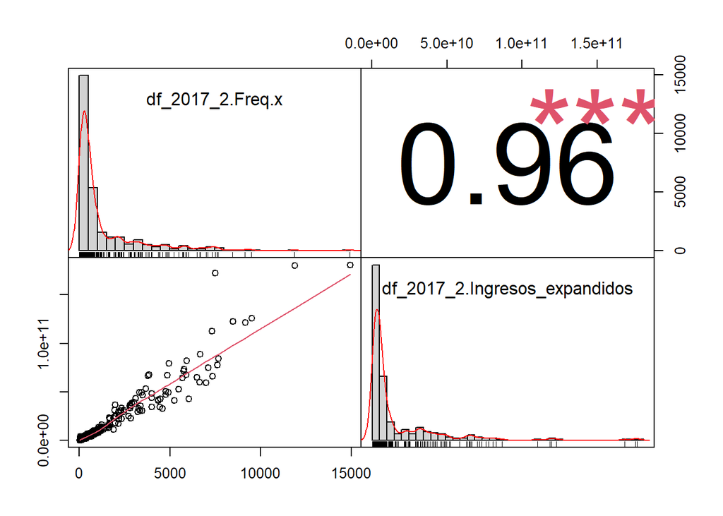

```r
dat1 <- data.frame(df_2017_2$Freq.x, df_2017_2$Ingresos_expandidos)
chart.Correlation(dat1)
```

#### Nivel 2:

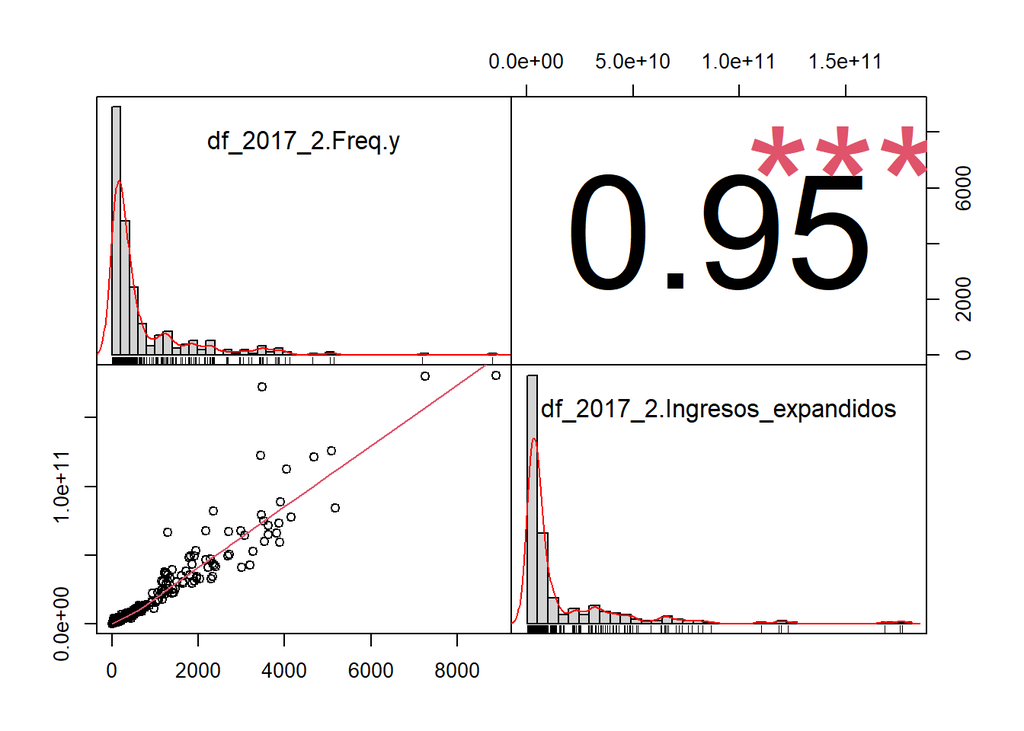

```r
dat1 <- data.frame(df_2017_2$Freq.y, df_2017_2$Ingresos_expandidos)
chart.Correlation(dat1)
```

#### Nivel 3:

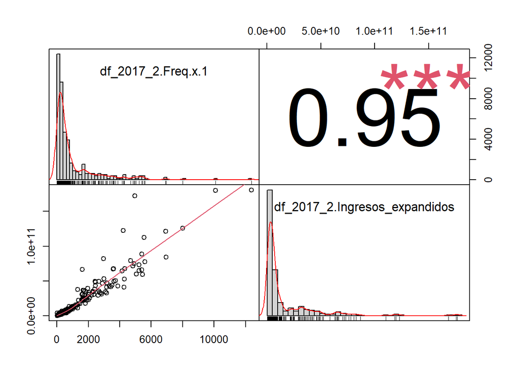

```r
dat1 <- data.frame(df_2017_2$Freq.x.1, df_2017_2$Ingresos_expandidos)
chart.Correlation(dat1)
```

#### Nivel 4:

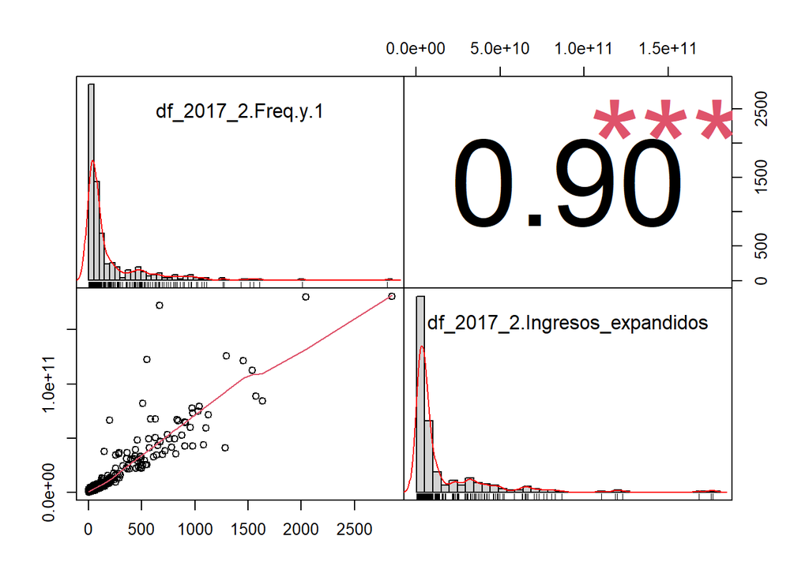

```r
dat1 <- data.frame(df_2017_2$Freq.y.1, df_2017_2$Ingresos_expandidos)
chart.Correlation(dat1)
```

#### Nivel 5:

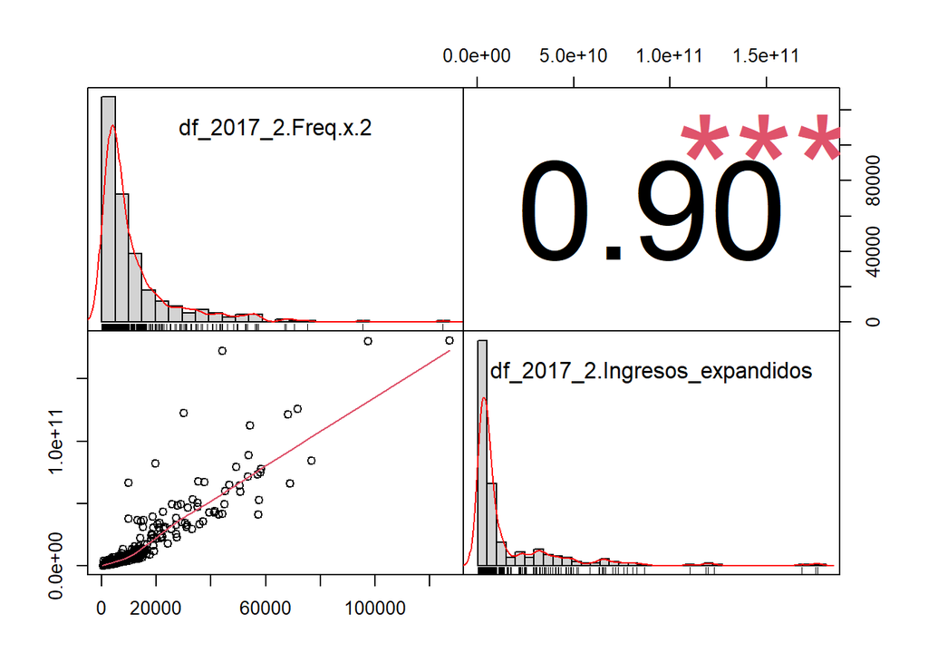

```r
dat1 <- data.frame(df_2017_2$Freq.x.2, df_2017_2$Ingresos_expandidos)
chart.Correlation(dat1)
```

#### Nivel 6:

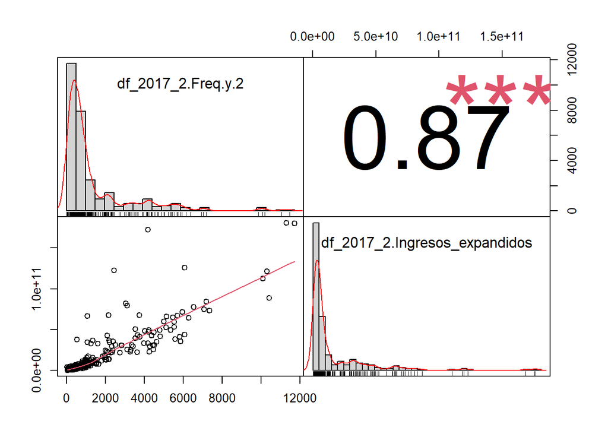

```r
dat1 <- data.frame(df_2017_2$Freq.y.2, df_2017_2$Ingresos_expandidos)
chart.Correlation(dat1)
```

#### Nivel 7:

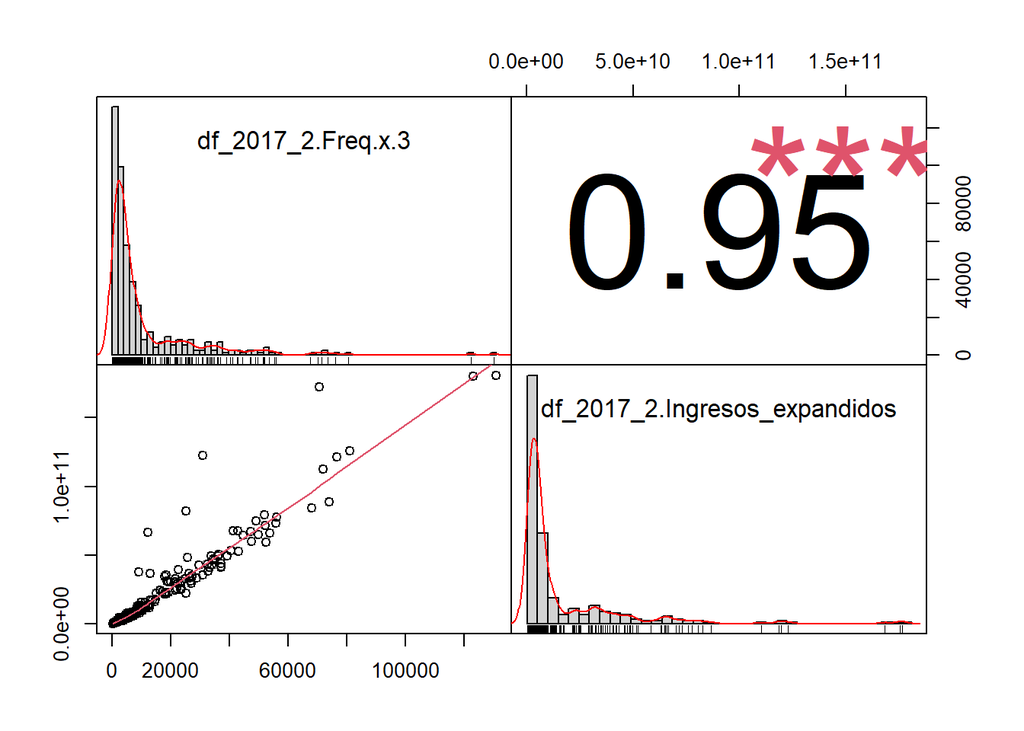

```r
dat1 <- data.frame(df_2017_2$Freq.x.3, df_2017_2$Ingresos_expandidos)
chart.Correlation(dat1)
```

#### Nivel 8:

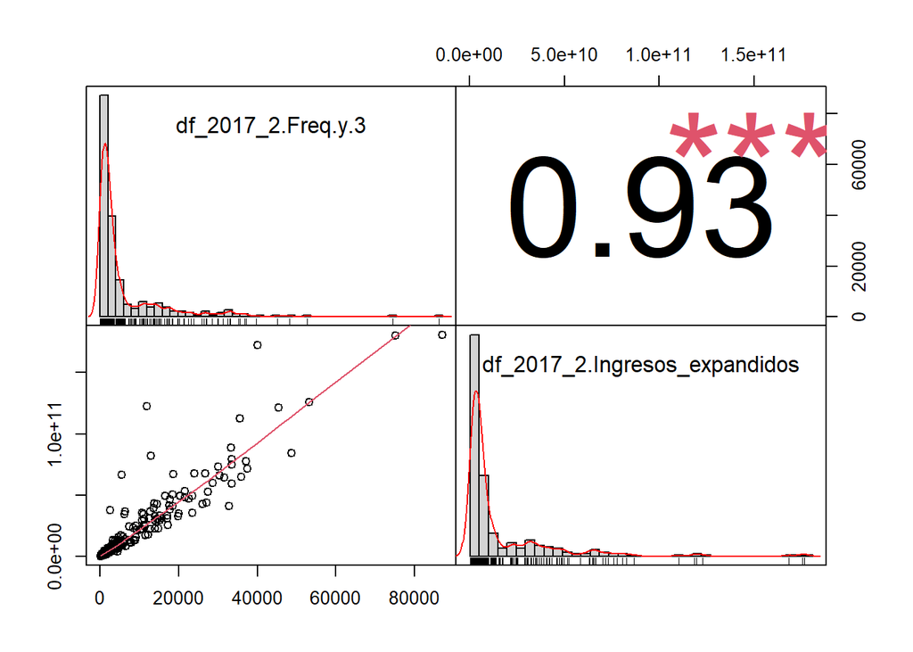

```r
dat1 <- data.frame(df_2017_2$Freq.y.3, df_2017_2$Ingresos_expandidos)
chart.Correlation(dat1)
```

#### Nivel 9:

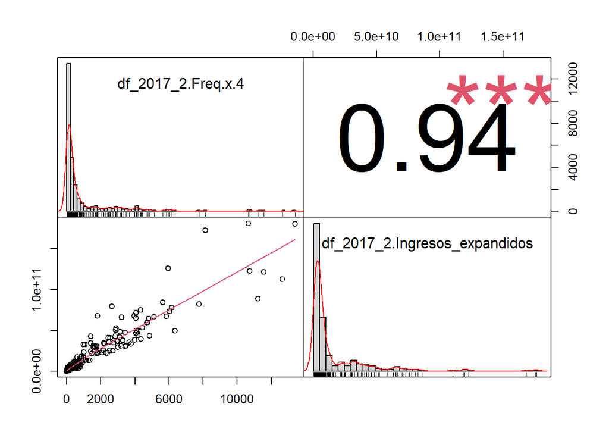

```r
dat1 <- data.frame(df_2017_2$Freq.x.4, df_2017_2$Ingresos_expandidos)
chart.Correlation(dat1)
```

#### Nivel 10:

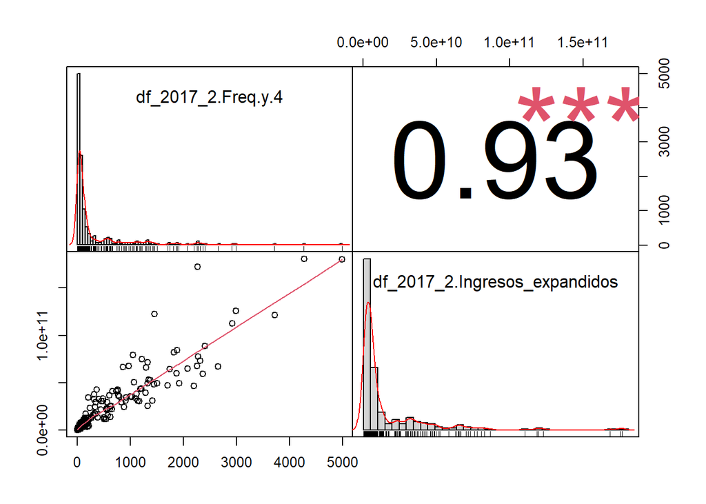

```r
dat1 <- data.frame(df_2017_2$Freq.y.4, df_2017_2$Ingresos_expandidos)
chart.Correlation(dat1)
```

#### Nivel 11:

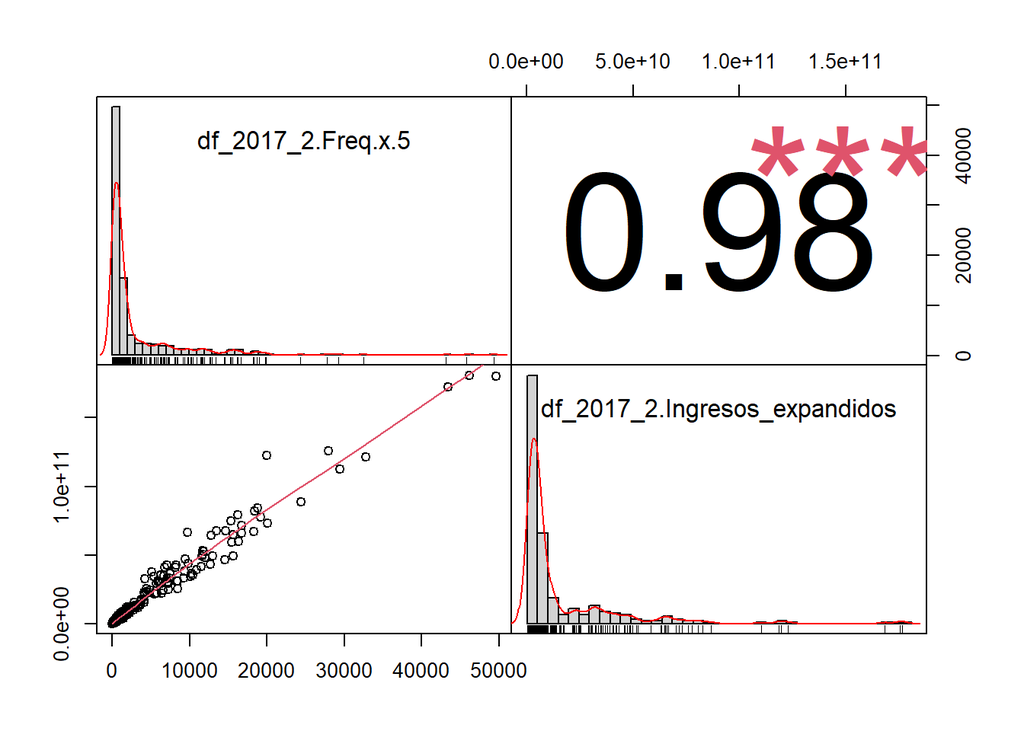

```r
dat1 <- data.frame(df_2017_2$Freq.x.5, df_2017_2$Ingresos_expandidos)
chart.Correlation(dat1)
```

#### Nivel 12:

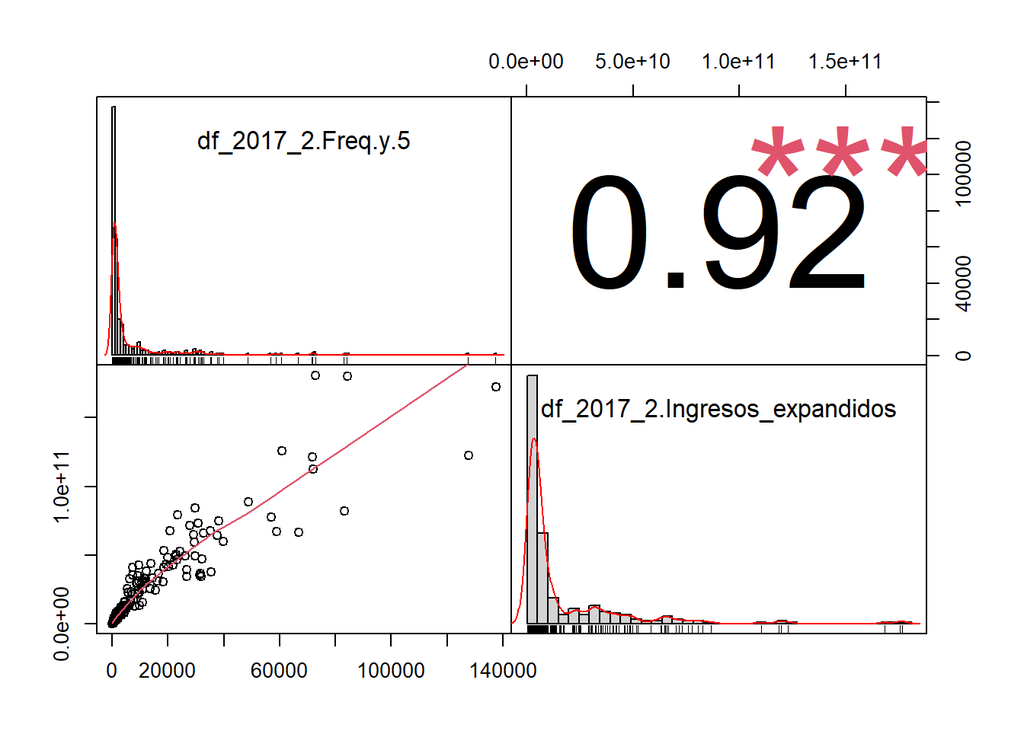

```r
dat1 <- data.frame(df_2017_2$Freq.y.5, df_2017_2$Ingresos_expandidos)
chart.Correlation(dat1)
```

#### Nivel 13:

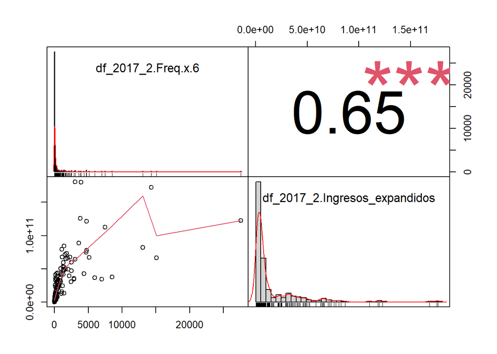

```r
dat1 <- data.frame(df_2017_2$Freq.x.6, df_2017_2$Ingresos_expandidos)
chart.Correlation(dat1)
```

#### Nivel 14:

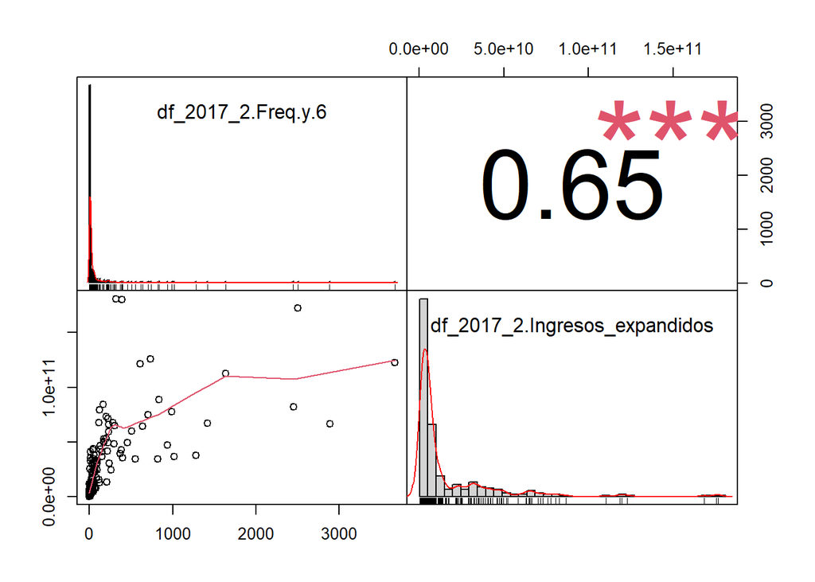

```r
dat1 <- data.frame(df_2017_2$Freq.y.6, df_2017_2$Ingresos_expandidos)
chart.Correlation(dat1)
```

### 1.4 **P16**: Se considera perteneciente a un pueblo indígena u originario?

1 Sí  
2 No  
98 No aplica  
99 Missing

1.4.1 Queremos saber la frecuencia de personas que se consideran pertenecientes a un pueblo indígena que viven por comuna:

Leemos la base de datos Censal:

```r
b <- tabla_con_clave$COMUNA
c <- tabla_con_clave$P16
cross_tab =  xtabs( ~ unlist(b) + unlist(c))
tabla <- as.data.frame(cross_tab)
d <-tabla[!(tabla$Freq == 0),]
names(d)[1] <- "comuna"
names(d)[2] <- "pertenencia_a_po"
tablamadre <- head(d,50)

kbl(tablamadre) %>%
  kable_styling(bootstrap_options = c("striped", "hover")) %>%
  kable_paper() %>%
  scroll_box(width = "100%", height = "300px")
```

| comuna | pertenencia_a_po | Freq |
| --- | --- | --- |
| 1101 | 1 | 33021 |
| 1107 | 1 | 32079 |
| 1401 | 1 | 6616 |
| 1402 | 1 | 1071 |
| 1403 | 1 | 1403 |
| 1404 | 1 | 1649 |
| 1405 | 1 | 4226 |
| 2101 | 1 | 28174 |
| 2102 | 1 | 1245 |
| 2103 | 1 | 1386 |
| 2104 | 1 | 3393 |
| 2201 | 1 | 39724 |
| 2202 | 1 | 215 |
| 2203 | 1 | 5523 |
| 2301 | 1 | 1965 |
| 2302 | 1 | 787 |
| 3101 | 1 | 27078 |
| 3102 | 1 | 3129 |
| 3103 | 1 | 4375 |
| 3201 | 1 | 1299 |
| 3202 | 1 | 1789 |
| 3301 | 1 | 12369 |
| 3302 | 1 | 2723 |
| 3303 | 1 | 1106 |
| 3304 | 1 | 1545 |
| 4101 | 1 | 18994 |
| 4102 | 1 | 18274 |
| 4103 | 1 | 692 |
| 4104 | 1 | 492 |
| 4105 | 1 | 364 |
| 4106 | 1 | 2984 |
| 4201 | 1 | 2090 |
| 4202 | 1 | 417 |
| 4203 | 1 | 1336 |
| 4204 | 1 | 2676 |
| 4301 | 1 | 11025 |
| 4302 | 1 | 1272 |
| 4303 | 1 | 2739 |
| 4304 | 1 | 1334 |
| 4305 | 1 | 267 |
| 5101 | 1 | 20153 |
| 5102 | 1 | 1674 |
| 5103 | 1 | 2288 |
| 5104 | 1 | 60 |
| 5105 | 1 | 1143 |
| 5107 | 1 | 2285 |
| 5109 | 1 | 20573 |
| 5201 | 1 | 3976 |
| 5301 | 1 | 3671 |
| 5302 | 1 | 849 |

Apilamos los registros comunales uno al lado del otro:

```r
library(dplyr)
d_1 <- filter(d,d$pertenencia_a_po == 1)
d_2 <- filter(d,d$pertenencia_a_po == 2)
d_12 = merge( x = d_1, y = d_2, by = "comuna", all.x = TRUE)
# d_12
```

```r
# v <- 1
# vv <- switch(v, glaciares_19_q1, glaciares_20_q1)
# vv
```

## 2 Referencias

https://rpubs.com/osoramirez/316691

https://dataintelligencechile.shinyapps.io/casenfinal

Manual_de_usuario_Censo_2017_16R.pdf

http://www.censo2017.cl/microdatos/

Censo de Población y Vivienda

https://www.ine.cl/estadisticas/sociales/censos-de-poblacion-y-vivienda/poblacion-y-vivienda